# Report Practical Machine Learning:

Mirna van Hoek

13 December 2017

# Goal

Devices like Jawbone Up, Nike Fuelband and Fitbit are used to collect a large amount of data about personal activity. The data is used to quantify how much of a particular activity a person does. But hardly ever do they quantify how well a person performs an activity. In this report data from accelerometers on belt, forearm and dumbell of 6 participants is analyzed. The goal is to predict the manner in which the participants performed the exercise.

Different models are defined and trained using the training set. The best model is chosen based on a validation set and the out of sample error. The best performing model is then used to predict the manner in which the activity is performed for the 20 observations in the test dataset.

# Dataset

For this analysis the Weight Lifting Exercise Dataset is used. Data is obtained from different accelerometers caried on the belt, forarm or dumbell of 6 pparticipants while they perform barbell lifts. The lifts are performed in 5 different ways: one correctly and 4 different ways to perform the lifts incorrectly. This is indicated by the “classe” variable in the training set, where “A” indicates that the lift is performed correctly[^1]. The data for this project come from this source: http://web.archive.org/web/20161224072740/http:/groupware.les.inf.puc-rio.br/har.

# Data Analysis

## Read training and test data from csv

```r
library(knitr)
library(caret)
library(parallel)
library(doParallel)
library(ggplot2)
```

```r
trainingCSV <- read.csv("pml-training.csv", as.is = TRUE, na.strings = c("NA", "#DIV/0!", ""))
testingCSV <- read.csv("pml-testing.csv", as.is = TRUE, na.strings = c("NA", "#DIV/0!", ""))
```

## Preprocessing

### Data Cleaning

The training data set consists of 19622 observations and 160 variables. The first 7 variables (“X”, “user_name”, “raw_timestamp_part_1”, “raw_timestamp_part_2”, “cvtd_timestamp”, “new_window”, “num_window”) seem meaningless for use of classifying how an activity was performed and are removed.

```r
training <- trainingCSV[,-c(1:7)]
testing <- testingCSV[,-c(1:7)]
```

Several variables have a lot of missing values. The near zero variance variables need to be removed.

```r
training[is.na(training)] = 0.
nzv <- nearZeroVar(training)
training <- training[-nzv]
testing <- testing[-nzv]
```

The cleaned-up training set consists of 19622 observations and 53 variables.

### Validation Sample

The training dataset is divided-up to create a training set to train the models and a validation set to asses the models.

```r
inTrain <- createDataPartition(y=training$classe, p=0.7, list=FALSE)
train <- training[inTrain,]
validation <- training[-inTrain,]
```

The validation dataset contains 5885 observations and the training set contains 13737 observables.

## Model building

Different models (Decision Tree, Gradient Boosting, Random Forest) are build and trained using the training set.

```r
cluster <- makeCluster(detectCores() - 1)
registerDoParallel(cluster)
fitControl <- trainControl(method='cv', number = 3, allowParallel=TRUE)
```

### Decision Tree

```r
model_rpart <- train( classe ~ ., data=train, trControl=fitControl, method='rpart')
```

### Gradient Boosting

```r
model_gbm <- train( classe ~ ., data=train, trControl=fitControl, method='gbm')
```

### Random Forest

```r
model_rf <- train( classe ~ ., data=train, trControl=fitControl, method='rf')
```

### Model Assesment

The models are assesed based on the out of sample error using the validation set.

```r
predRPART <- predict(model_rpart, newdata=validation)
cmRPART <- confusionMatrix(predRPART, validation$classe)
predGBM <- predict(model_gbm, newdata=validation)
cmGBM <- confusionMatrix(predGBM, validation$classe)
predRF <- predict(model_rf, newdata=validation)
cmRF <- confusionMatrix(predRF, validation$classe)

AccuracyResults <- data.frame( Model = c('RPART', 'GBM', 'RF'), Accuracy = rbind(cmRPART$overall[1], cmGBM$overall[1], cmRF$overall[1]))
print(AccuracyResults)
```

```
##   Model  Accuracy
## 1 RPART 0.4919286
## 2   GBM 0.9600680
## 3    RF 0.9926933
```

In figures 1-3 in the Appendix the confusion matrices for the different models are plotted. As can be seen the Random Forest model performs the best/has the best predictions, i.e. is the most accurate since most observations in the confusion matrix end up on the diagonal and less observations end up on the off-diagonal (so smaller out of sample error). Based on the accuracy results the Random Forest Model, with an accuracy of 0.9926933, has the highest accuracy (and thus the smalles out of sample error (0.0073067)), therefore, the Random Forest Model is the best model.

## Prediction

Using the best model (random forest) from the previous section for each of the 20 observations in the test sample is predicted in what manner the lifts were performed.

```r
predTest <- predict(model_rf, newdata=testing)
TestPredictionResults <- data.frame( problem_id=testing$problem_id, predicted=predTest)
    print(TestPredictionResults)
```

```
##    problem_id predicted
## 1           1         B
## 2           2         A
## 3           3         B
## 4           4         A
## 5           5         A
## 6           6         E
## 7           7         D
## 8           8         B
## 9           9         A
## 10         10         A
## 11         11         B
## 12         12         C
## 13         13         B
## 14         14         A
## 15         15         E
## 16         16         E
## 17         17         A
## 18         18         B
## 19         19         B
## 20         20         B
```

# Appendix

Confusion Matrix plots for the different models. The more observations are on the diagonal of the confusion matrix the more accurate the model predicts. The less observations are on the off-diagonal of the confusion matrix the lower the out of sample error is.

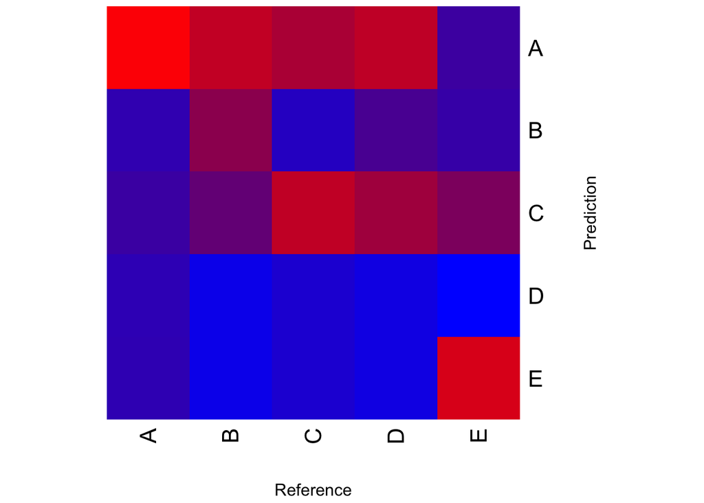

Figure 1. Confusion Matrix plot for RPART model

```r
heatmap(cmRPART$table, Rowv=NA, Colv=NA, scale="column", col=colorRampPalette(c("blue", "red"))(255), revC=T, xlab="Reference", ylab="Prediction" )
```

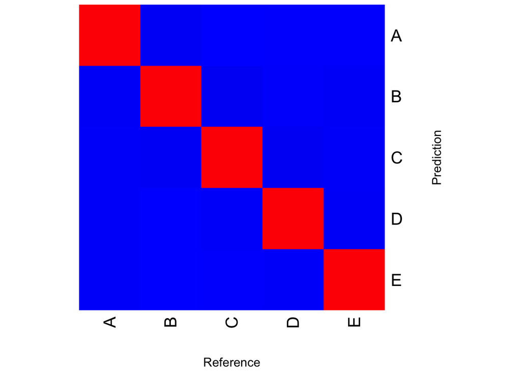

Figure 2. Confusion Matrix plot for GBM model

```r
heatmap(cmGBM$table, Rowv=NA, Colv=NA, scale="column", col=colorRampPalette(c("blue", "red"))(255), revC=T, xlab="Reference", ylab="Prediction" )
```

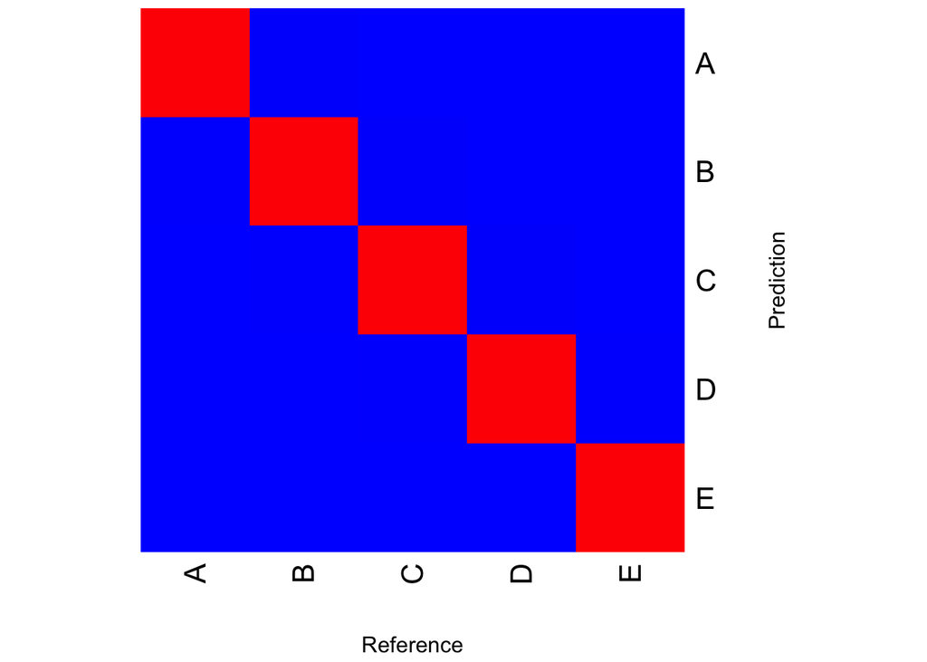

Figure 3. Confusion Matrix plot for RF model

```r
heatmap(cmRF$table, Rowv=NA, Colv=NA, scale="column", col=colorRampPalette(c("blue", "red"))(255), revC=T, xlab="Reference", ylab="Prediction" )
```

[^1]: Source: Velloso, E.; Bulling, A.; Gellersen, H.; Ugulino, W.; Fuks, H. Qualitative Activity Recognition of Weight Lifting Exercises. Proceedings of 4th International Conference in Cooperation with SIGCHI (Augmented Human ’13) . Stuttgart, Germany: ACM SIGCHI, 2013.